# Wavelet Matrix Overview

Sara Antonijevic

```r
library(WaveletMatrixProject)
```

# Introduction

The `WaveletMatrixProject` is a package built for the construction and manipulation of wavelets and wavelet transformation matrices. These tools are essential for signal processing tasks, such as:

- Decomposing signals into multiple resolutions.
- Analyzing frequency components across different scales.
- Enhancing feature extraction, and reconstructing signals from wavelet transformations.

This vignette serves as a guide to the package, composing of:

- **Detailed Core-Function Descriptions**: Clear explanations of each function’s purpose and role in signal processing.
- **Code Examples**: Step-by-step demonstrations to help you understand usage.
- **Visual Outputs**: Graphs and plots to illustrate the effects of transformations.

By the end of this vignette, you will be able to:

- Construct wavelets and wavelet packet matrices using the functions.
- Apply advanced transformations for multi-resolution signal analysis.
- Combine supporting utilities like filter dilation and vector embedding to enhance workflow.

# Core Functions

## 1. `WavmatND()`

**Description**: The WavmatND() function generates a wavelet matrix by applying a high-pass filter to an identity matrix. This then constructs a transformation matrix that captures the high-frequency details of a signal. The function is useful in non-decimated wavelet transforms where no down-sampling is performed. Therefore, it preserves the original signal length.

**Key Arguments**:

- **hf**: Vector of high-pass filter coefficients.
- **N**: Size of the wavelet matrix (signal length).
- **k**: Decomposition levels.
- **shift**: Shift needed to be applied to the filter at each iteration.

WavmatND() supports multi-resolution analysis by enabling signal decomposition at finer scales.

### Example

```r
# Define parameters
hf <- c(0.5, -0.5) # High-pass filter
N <- 4  # Signal length
k <- 3  # Decomposition levels
shift <- 1  # Filter shift

# Construct the wavelet matrix
W <- WavmatND(hf, N, k, shift)
print(W)
```

```
#>         [,1]   [,2]   [,3]   [,4]
#>  [1,] -0.125 -0.125  0.125  0.125
#>  [2,]  0.125 -0.125 -0.125  0.125
#>  [3,]  0.125  0.125 -0.125 -0.125
#>  [4,] -0.125  0.125  0.125 -0.125
#>  [5,]  0.125  0.125 -0.125 -0.125
#>  [6,] -0.125  0.125  0.125 -0.125
#>  [7,] -0.125 -0.125  0.125  0.125
#>  [8,]  0.125 -0.125 -0.125  0.125
#>  [9,] -0.250  0.250 -0.250  0.250
#> [10,]  0.250 -0.250  0.250 -0.250
#> [11,] -0.250  0.250 -0.250  0.250
#> [12,]  0.250 -0.250  0.250 -0.250
#> [13,]  0.000 -0.500 -0.500  0.000
#> [14,]  0.000  0.000 -0.500 -0.500
#> [15,] -0.500  0.000  0.000 -0.500
#> [16,] -0.500 -0.500  0.000  0.000
```

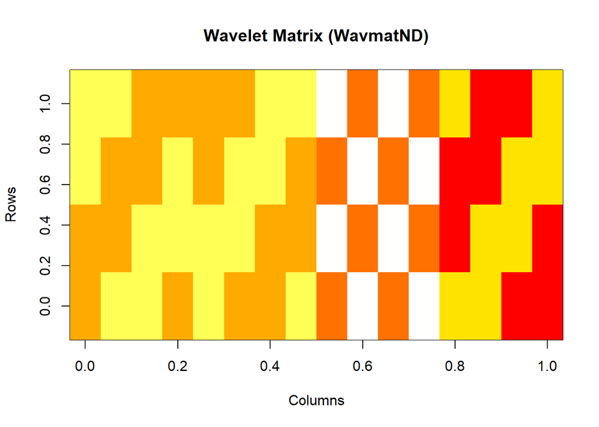

```r
# Visualizing the wavelet matrix
image(W, main = "Wavelet Matrix (WavmatND)", xlab = "Columns", ylab = "Rows", col = heat.colors(256))
```

**Explanation**: The WavmatND() function starts with an identity matrix and applies a high-pass filter to construct the wavelet matrix. This matrix can be used for signal processing tasks where transformations are needed to capture specific frequency components in signals.

**Supporting Functions**:

- **dilate_filter()**: Dilates the filter coefficients for higher decomposition levels.
- **imbed()**: Embeds a vector by appending zeros.
- **repeating()**: Creates repeated sequences from input vectors.

## 2. `WavPackMatWP()`

**Description**: Constructs a wavelet packet transformation matrix using a low-pass filter. This matrix represents a transformation that decomposes signals into components at different levels of detail.

**Key Arguments:**

- **h**: Vector for the low-pass filter.
- **N**: Size of the matrix (must be a power of 2).
- **k0**: Depth of the wavelet transformation.
- **shift**: Shifts in the wavelet transformation (default is 2).

### Example

```r
# Low-pass filter
h <- c(0.5, 0.5) #Low-pass filer
N <- 8 #Signal size (must be a power of 2, 2^3 in this case)
k0 <- 2 #Depth of decomposition
shift <- 2 #Shift parameter

# Construct the wavelet packet matrix
WP <- WavPackMatWP(h, N, k0, shift)
print(WP)
```

```
#>            [,1]       [,2]       [,3]       [,4]      [,5]
#>  [1,] 0.3535534  0.3535534  0.0000000  0.0000000 0.0000000
#>  [2,] 0.0000000  0.0000000  0.3535534  0.3535534 0.0000000
#>  [3,] 0.0000000  0.0000000  0.0000000  0.0000000 0.3535534
#>  [4,] 0.0000000  0.0000000  0.0000000  0.0000000 0.0000000
#>  [5,] 0.3535534 -0.3535534  0.0000000  0.0000000 0.0000000
#>  [6,] 0.0000000  0.0000000  0.3535534 -0.3535534 0.0000000
#>  [7,] 0.0000000  0.0000000  0.0000000  0.0000000 0.3535534
#>  [8,] 0.0000000  0.0000000  0.0000000  0.0000000 0.0000000
#>  [9,] 0.1767767  0.1767767  0.1767767  0.1767767 0.0000000
#> [10,] 0.0000000  0.0000000  0.0000000  0.0000000 0.1767767
#> [11,] 0.1767767  0.1767767 -0.1767767 -0.1767767 0.0000000
#> [12,] 0.0000000  0.0000000  0.0000000  0.0000000 0.1767767
#> [13,] 0.1767767 -0.1767767  0.1767767 -0.1767767 0.0000000
#> [14,] 0.0000000  0.0000000  0.0000000  0.0000000 0.1767767
```

[output cut: 19 more lines]

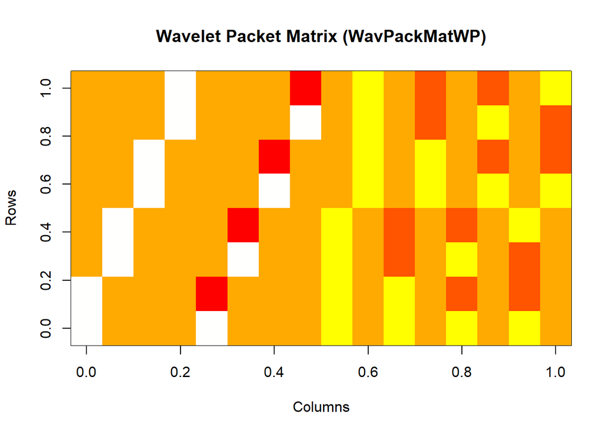

```r
# Visualizing the wavelet packet matrix
image(WP, main = "Wavelet Packet Matrix (WavPackMatWP)", xlab = "Columns", ylab = "Rows", col = heat.colors(256))
```

**Explanation**: WavPackMatWP() builds a matrix for wavelet packet transformation up to a depth k0. It uses the low-pass filter (h) to decompose the signal and create a matrix that captures different levels of detail. This function is essential for performing multi-resolution analysis.

**Supporting Functions:** - **getsubWP():** This function constructs sub-matrices for the wavelet packet transformation at each decomposition level. It applies low-pass (h) and high-pass (g) filters which generate sub-matrices that represent transformations at different decomposition levels.

- **Key Components of `getsubWP()`**:
  - **Iterative construction**: `getsubWP()` builds sub-matrices by applying filters at each level in reverse order.
  - **Filter applications**: Combines h and g matrices to decompose the signal at its current level.
- **Arguments in `getsubWP()`**:
  - **jstep**: Current decomposition level.
  - **h**: Low-pass filter.
  - **g**: High-pass filter.
  - **J**: Maximum number of decomposition levels.
  - **N**: Size of signal/matrix.

**getHGmatWP():** This function computes matrices using the input filters (h and g), adjusting their elements with a modulus operation to handle boundary conditions. This helps ensure that the transformation correctly wraps around indices when applying the filters.

**Key Components of `getHGmatWP()`**:

- **Arguments in `getHGmatWP()`**:
  - **k**: Current decomposition level.
  - **h**: Low-pass filter.
  - **g**: High-pass filter.
  - **J**: Maximum number of decomposition levels.
  - **N**: Size of signal/matrix.

## 3. `WavPackMat()`

**Description**: This function constructs an optimized orthogonal wavelet transformation matrix using a low-pass filter. This matrix is used for efficient wavelet-based signal processing.

### Example

```r
# Low-pass filter
h <- c(0.5, 0.5)

# Parameters for wavelet transformation matrix
N <- 8 #Matrix size (2^3 in this case)
k0 <- 3 #Depth of wavelet decomposition
shift <- 2 #Shift parameter

# Construct the wavelet transformation matrix
WP_opt <- WavPackMat(h, N, k0, shift)
print(WP_opt)
```

```
#>             [,1]        [,2]        [,3]        [,4]        [,5]
#>  [1,] 0.28867513  0.28867513  0.00000000  0.00000000  0.00000000
#>  [2,] 0.00000000  0.00000000  0.28867513  0.28867513  0.00000000
#>  [3,] 0.00000000  0.00000000  0.00000000  0.00000000  0.28867513
#>  [4,] 0.00000000  0.00000000  0.00000000  0.00000000  0.00000000
#>  [5,] 0.28867513 -0.28867513  0.00000000  0.00000000  0.00000000
#>  [6,] 0.00000000  0.00000000  0.28867513 -0.28867513  0.00000000
#>  [7,] 0.00000000  0.00000000  0.00000000  0.00000000  0.28867513
#>  [8,] 0.00000000  0.00000000  0.00000000  0.00000000  0.00000000
#>  [9,] 0.14433757  0.14433757  0.14433757  0.14433757  0.00000000
#> [10,] 0.00000000  0.00000000  0.00000000  0.00000000  0.14433757
#> [11,] 0.14433757  0.14433757 -0.14433757 -0.14433757  0.00000000
#> [12,] 0.00000000  0.00000000  0.00000000  0.00000000  0.14433757
#> [13,] 0.14433757 -0.14433757  0.14433757 -0.14433757  0.00000000
#> [14,] 0.00000000  0.00000000  0.00000000  0.00000000  0.14433757
```

[output cut: 35 more lines]

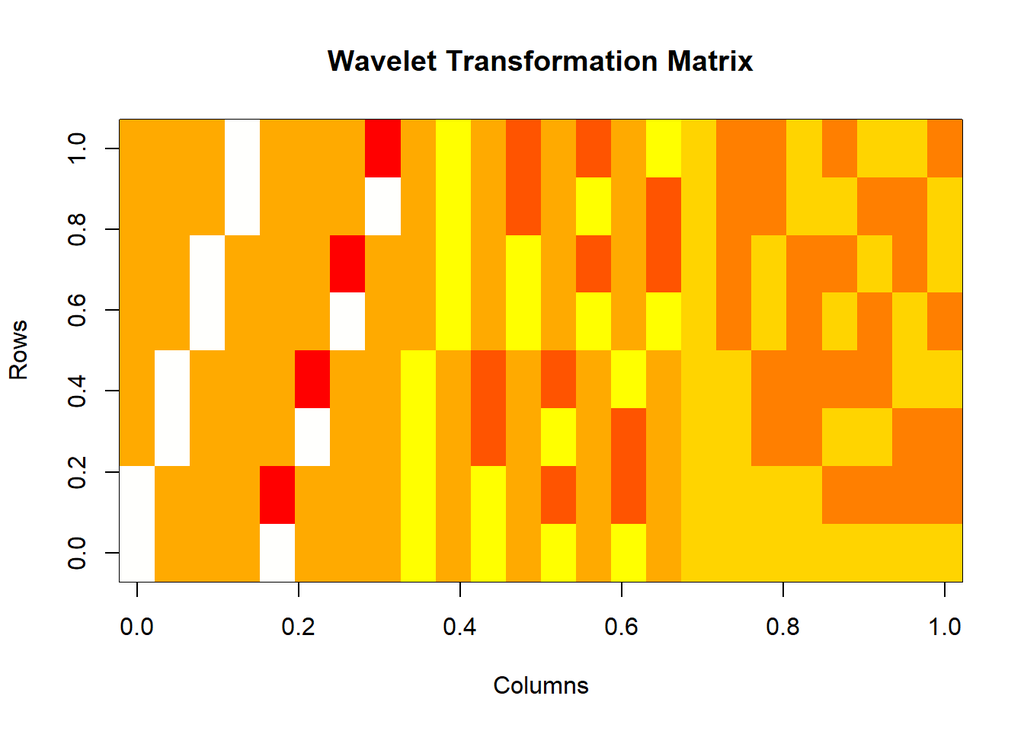

```r
# Visualize the matrix
image(WP_opt, main = "Wavelet Transformation Matrix", xlab = "Columns", ylab = "Rows", col = heat.colors(256))
```

**Explanation**: WavPackMat() uses the low-pass filter (h) to create an orthogonal matrix for efficient decomposition and reconstruction.

**Supporting Functions:** **getsubW():** Constructs sub-matrices for the wavelet transformation at each level. It applies the H and G matrices at each iteration to create sub-matrices for each decomposition level, which is essential for building the wavelet matrix used for signal decomposition.

**Key Components of `getsubW()`**:

- **Arguments in `getsubW()`**:
  - **jstep**: Current decomposition level.
  - **h**: Low-pass filter.
  - **g**: High-pass filter.
  - **J**: Maximum number of decomposition levels.
  - **N**: Size of the matrix.

**getHGmat():** This function creates h and g matrices that are critical for constructing wavelet transformations with circular boundary conditions. The matrices ensure that the input signal is properly processed even when indices wrap around.

**Key Components of `getHGmat()`**:

- **Matrix Construction**: Creates the h and g matrices by applying the low-pass (h) and high-pass (g) filters.
- **Boundary Handling**: Uses modulus operations to wrap around indices, ensuring the matrix respects circular boundary conditions.
- **Arguments in `getHGmat()`**:
  - **k**: Current decomposition level.
  - **h**: Low-pass filter.
  - **g**: High-pass filter.
  - **J**: Maximum number of decomposition levels.
  - **N**: Size of the matrix.

# Demo

## Wavmat.R Demo

**Demo 1:** Image Processing on Lena Data

```r
# Define wavelet filter from wavelets package
h <- c(-0.075765714789341, -0.029635527645954, 0.497618667632458,
       0.803738751805216, 0.297857795605542, -0.099219543576935,
       -0.012603967262261, 0.032223100604071)

# Load the Lena dataset (assuming it is available as a grayscale matrix)
data("lena")

# Transform lena data to match MATLAB's transformation of image data
A_full <- 255 - t(lena)

# Extract the central 256x256 portion for transformation
center_start <- (512 - 256) / 2 + 1
center_end <- center_start + 255
A <- A_full[center_start:center_end, center_start:center_end]

# Apply padding to the 256x256 submatrix as per MATLAB code
A[, 1:4] <- 255
A[, (ncol(A)-3):ncol(A)] <- 255
A[1:4, ] <- 255
A[(nrow(A)-3):nrow(A), ] <- 255

# Display the padded and transformed 256x256 Lena image using imager
imager::display(imager::as.cimg(A), main = "Padded and Transformed Lena Image (256x256)")


# Plot using base R
par(mfrow = c(2, 2))
image(A, col = gray.colors(256), main = "Padded and Transformed Lena Image (256x256)", useRaster = TRUE)

# Create wavelet matrix using WavPackMat with 256x256 size
N <- 256
k0 <- 2
W <- WavPackMat(h, N, k0)

# Apply the wavelet transformation: B = W * A * W'
B <- W %*% A %*% t(W)

# Display the transformed image using imager
imager::display(imager::as.cimg(B), main = "Transformed Lena Image (B)", rescale = FALSE)



# Plot using base R
image(B, col = gray.colors(256), main = "Transformed Lena Image (B)", zlim = c(0, 20), useRaster = TRUE)

# Inverse transformation: C = W' * B * W
C <- t(W) %*% B %*% W
imager::display(imager::as.cimg(C), main = "Inverse Transformed Image (C)")

# Plot using base R
image(C, col = gray.colors(256), main = "Inverse Transformed Image (C)", useRaster = TRUE)

# Difference image: D = A - C
D <- A - C
imager::display(imager::as.cimg(D), main = "Difference Image (D)", rescale = FALSE)

# Check the range of values in D
cat("Min of D:", min(D), "\n")
```

```
#> Min of D: 3.222453e-10
```

```r
cat("Max of D:", max(D), "\n")
```

```
#> Max of D: 3.236664e-10
```

[figure not shown]

```r
# Plot D with an adjusted zlim range
image(D, col = gray.colors(256), main = "Difference Image (D)", zlim = range(D), useRaster = TRUE)
```

```r
# Scale D for better visualization
D_scaled <- D * 1000

# Checking the range of D_scaled
cat("Min of D_scaled:", min(D_scaled), "\n")
```

```
#> Min of D_scaled: 3.222453e-07
```

```r
cat("Max of D_scaled:", max(D_scaled), "\n")
```

```
#> Max of D_scaled: 3.236664e-07
```

```r
# Display using base R
image(D_scaled, col = gray.colors(256), main = "Scaled Difference Image (D)", useRaster = TRUE)

# Normalize D_scaled for imager display
D_scaled_normalized <- (D_scaled - min(D_scaled)) / (max(D_scaled) - min(D_scaled))
imager::display(imager::as.cimg(D_scaled_normalized), main = "Scaled and Normalized Difference Image (D)")



# Debugging Outputs
cat("Mean of A:", mean(A), "\n")
```

```
#> Mean of A: 254.5496
```

```r
cat("Mean of B:", mean(B), "\n")
```

```
#> Mean of B: 46.36336
```

```r
cat("Mean of C:", mean(C), "\n")
```

```
#> Mean of C: 254.5496
```

```r
cat("Mean of D:", mean(D), "\n") #should be approximately 0
```

```
#> Mean of D: 3.229099e-10
```

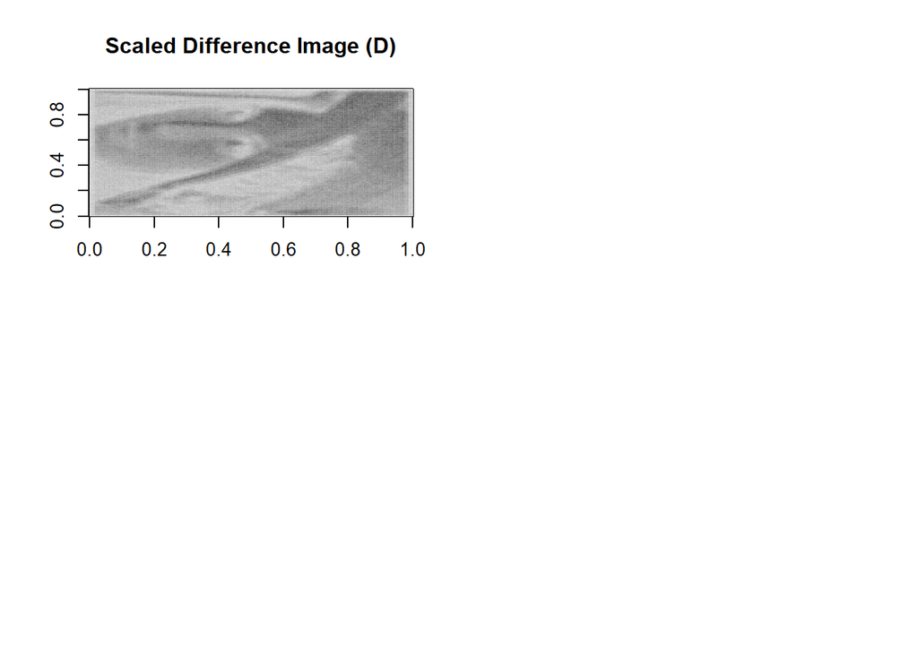

**Explanation**

This demo illustrates the application of wavelet transformations to the Lena image (standard image processing data file). The image is preprocessed by inverting pixel intensities, cropped to a 256x256 portion for focus. Then, the padding to handle boundary effects during transformation is placed. Using a wavelet filter, the wavelet transformation matrix decomposes the image into multi-resolution components,which highlight details like edges and textures while at the same time preserving broader structures.

Then, we reconstruct with the inverse transformation demonstrates high fidelity. This gives a minimal difference in images that quantify transformation accuracy. This process showcases how wavelets are utilized in tasks such as image compression, noise reduction, and feature extraction.

**Demo 2:** Signal Denoising

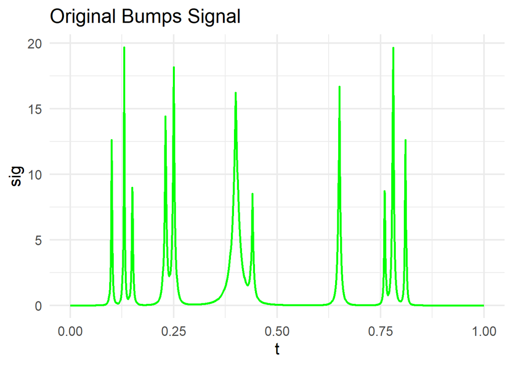

```r
#Generate the "bumps" signal
N <- 1024 # Number of points in the signal
t <- seq(0, 1, length.out = N) # Time vector


# Define the positions, heights, and widths of the bumps
pos <- c(0.1, 0.13, 0.15, 0.23, 0.25, 0.40, 0.44, 0.65, 0.76, 0.78, 0.81)
hgt <- c(4, 5, 3, 4, 5, 4.2, 2.1, 4.3, 3.1, 5.1, 4.2)
wth <- c(0.005, 0.005, 0.006, 0.01, 0.01, 0.03, 0.01, 0.01, 0.005, 0.008, 0.005)

# Initialize the signal and add each bump
sig <- numeric(N)
for (j in 1:length(pos)) {
  sig <- sig + hgt[j] / (1 + abs((t - pos[j]) / wth[j]))^4
}


# Standardize the signal for a fixed Signal-to-Noise Ratio (SNR)
SNR <- 7# Desired SNR
sig <- sig * sqrt(SNR) / sd(sig) # Scale signal to achieve the target SNR


# Plot the original signal
ggplot2::ggplot(data.frame(t = t, sig = sig), ggplot2::aes(x = t, y = sig)) +
  ggplot2::geom_line(color = "green", size = 1) +
  ggplot2::theme_minimal(base_size = 16) +
  ggplot2::ggtitle("Original Bumps Signal")
```

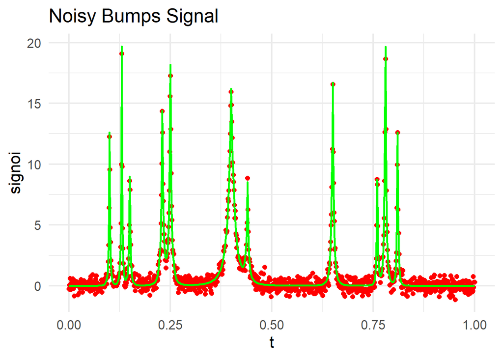

```r
# Add noise to the signal
set.seed(1)# Set seed for reproducibility
signoi <- sig + 1/sqrt(SNR) * rnorm(N) # Add Gaussian noise to the signal


#Plot the noisy signal
ggplot2::ggplot(data.frame(t = t, signoi = signoi, sig = sig), ggplot2::aes(x = t)) +
  ggplot2::geom_point(ggplot2::aes(y = signoi), color = "red", size = 2) +
  ggplot2::geom_line(ggplot2::aes(y = sig), color = "green", size = 1) +
  ggplot2::theme_minimal(base_size = 16) +
  ggplot2::ggtitle("Noisy Bumps Signal")
```

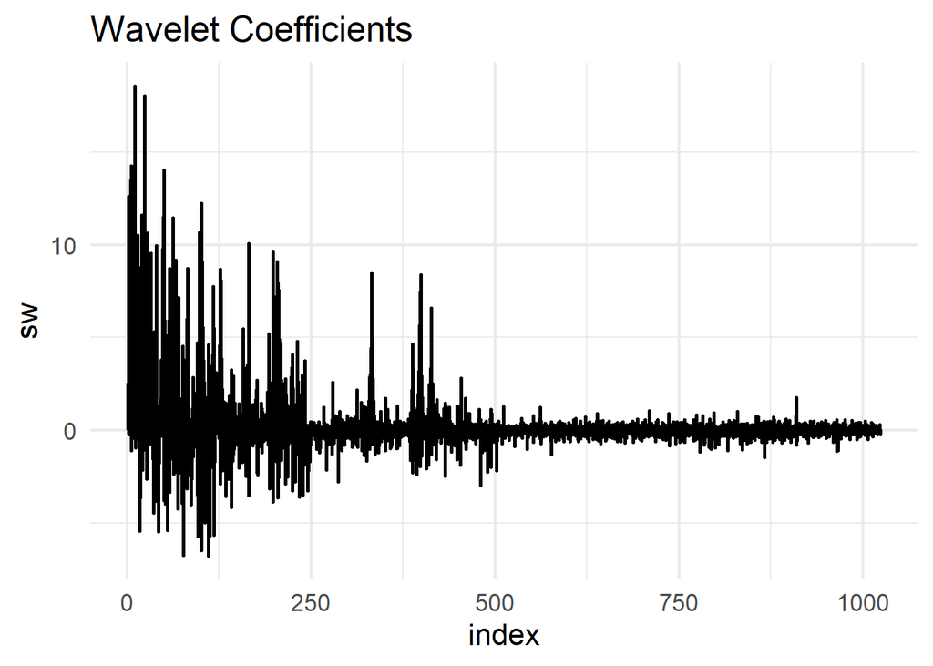

```r
#Create the wavelet transformation matrix using WavPackMat
filt <- c(-0.07576571478934, -0.02963552764595,
          0.49761866763246, 0.80373875180522,
          0.29785779560554, -0.09921954357694,
          -0.01260396726226, 0.03222310060407)

WP <- WavPackMat(filt, N, k0 = 6)# Generate the wavelet packet transformation matrix



#Transform the signal using the wavelet packet matrix
sw <- as.vector(WP %*% signoi)# Compute wavelet coefficients



# Plot the wavelet coefficients
ggplot2::ggplot(data.frame(index = 1:N, sw = sw), ggplot2::aes(x = index, y = sw)) +
  ggplot2::geom_line(size = 1) +
  ggplot2::theme_minimal(base_size = 16) +
  ggplot2::ggtitle("Wavelet Coefficients")
```

[figure not shown]

```r
#Threshold the small coefficients
finest <- sw[(N/2+1):N] # Select the finest level coefficients and estimate noise level
sigmahat <- sd(finest)# Estimate noise standard deviation
lambda <- sqrt(2 * log(N)) * sigmahat# Calculate the soft-threshold

# Apply soft-thresholding to wavelet coefficients
swt <- sign(sw) * pmax(abs(sw) - lambda, 0)
swt_length <- length(swt)

# Convert and display the thresholded wavelet coefficients as an image
swt_img <- imager::as.cimg(matrix(swt, nrow = 1, ncol = swt_length))
plot(swt_img, main = "Thresholded Wavelet Coefficients Image Representation")
```

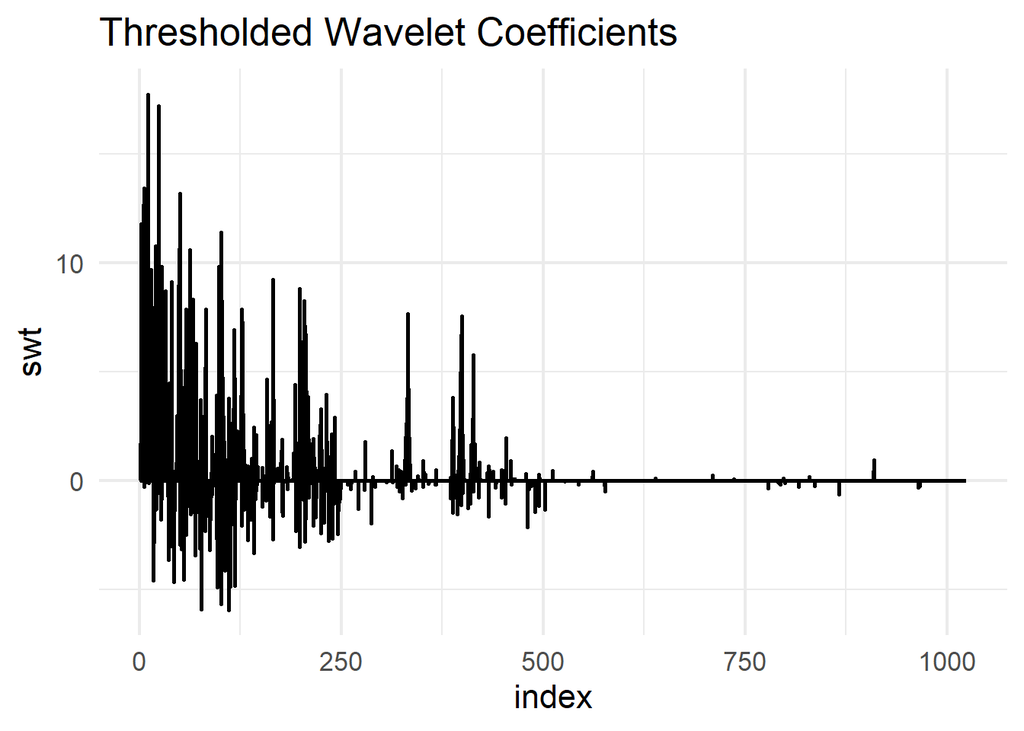

```r
# Plot the thresholded coefficients
ggplot2::ggplot(data.frame(index = 1:N, swt = swt), ggplot2::aes(x = index, y = swt)) +
  ggplot2::geom_line(size = 1) +
  ggplot2::theme_minimal(base_size = 16) +
  ggplot2::ggtitle("Thresholded Wavelet Coefficients")
```

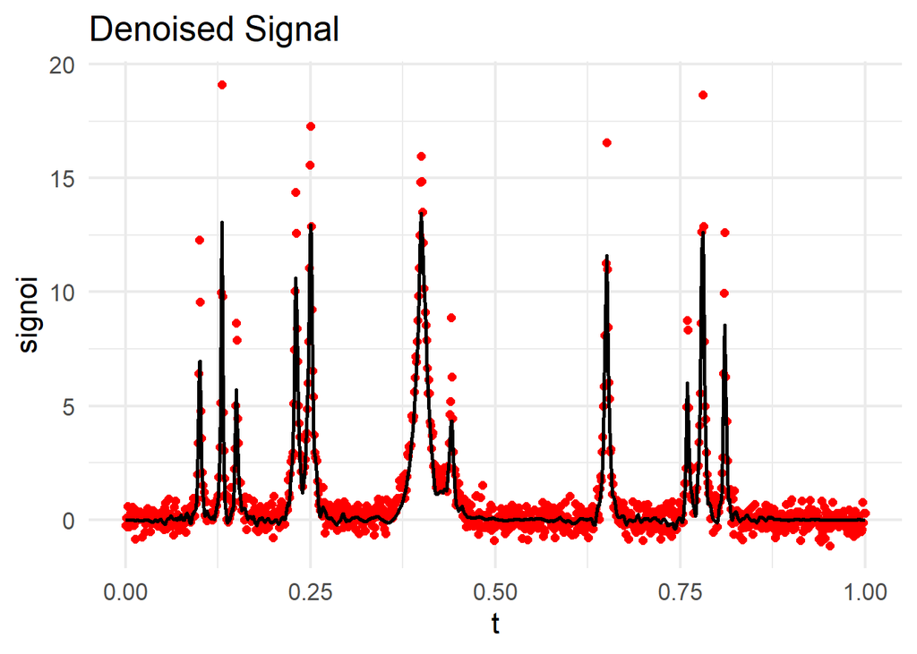

```r
#  Return the signal to the time domain using the inverse transformation
a <- as.vector(t(WP) %*% swt) # Reconstruct the signal

#Plot the denoised signal and the noisy signal for comparison
ggplot2::ggplot(data.frame(t = t, signoi = signoi, a = a), ggplot2::aes(x = t)) +
  ggplot2::geom_point(ggplot2::aes(y = signoi), color = "red", size = 2) +
  ggplot2::geom_line(ggplot2::aes(y = a), color = "black", size = 1) +
  ggplot2::theme_minimal(base_size = 16) +
  ggplot2::ggtitle("Denoised Signal")
```

**Explanation:**

This demo demonstrates thow wavelet transformations are utilized in signal denoising by using a synthetic “bumps” signal. The signal is constructed with multiple localized features (bumps) of varying heights and widths. This is done to simulate a plausible real-world scenario where signals contain sharp transitions. We then add noise to this simulated signal in order to simulate environmental interference (which is common in signal processing).

Using a wavelet packet transformation matrix constructed with a wavelet filter, the noisy signal is decomposed into wavelet coefficients. These coefficients represent the signal at different resolution levels,which allow for manipulation. A soft-thresholding technique is applied to remove small coefficients while preserving the larger coefficients that capture the signal’s key features.

The denoised signal is reconstructed by applying the inverse transformation to the thresholded coefficients, restoring the original signal with minimal noise. This approach highlights how wavelets are used in removing noise while retaining critical signal characteristics.

## WavmatWP.R

**Demo 1:** Transformation and Reconstruction

```r
library(WaveletMatrixProject)

# Define the filter ( coefficients define the specific wavelet used for the transformation)
filt <- c(-0.07576571478934, -0.02963552764595,
          0.49761866763246, 0.80373875180522,
          0.29785779560554, -0.09921954357694,
          -0.01260396726226, 0.03222310060407)
# Print to verify
print(filt)
```

```
#> [1] -0.07576571 -0.02963553  0.49761867  0.80373875  0.29785780
#> [6] -0.09921954 -0.01260397  0.03222310
```

```r
# Set parameters for the wavelet packet transformation matrix
N <- 8  # Size of the matrix
k0 <- 3  # Levels of decomposition
shift <- 0  # Shift parameter

# Generate the wavelet packet transformation matrix
WP <- WavPackMatWP(filt, N, k0, shift)

# Print the matrix
print(WP)
```

```
#>                [,1]          [,2]         [,3]          [,4]
#>  [1,] -0.0437433558 -0.0171100799  0.287300272  0.4640387847
#>  [2,] -0.0072769039  0.0186040158 -0.043743356 -0.0171100799
#>  [3,]  0.1719682785 -0.0572844302 -0.007276904  0.0186040158
#>  [4,]  0.2873002717  0.4640387847  0.171968278 -0.0572844302
#>  [5,]  0.0186040158  0.0072769039 -0.057284430 -0.1719682785
#>  [6,] -0.0171100799  0.0437433558  0.018604016  0.0072769039
#>  [7,]  0.4640387847 -0.2873002717 -0.017110080  0.0437433558
#>  [8,] -0.0572844302 -0.1719682785  0.464038785 -0.2873002717
#>  [9,]  0.3200188889  0.3452051694  0.114125293 -0.0714351748
#> [10,] -0.0491598348 -0.0029733651  0.103262717  0.2174504353
#> [11,] -0.1041385041 -0.1328506899 -0.041793716  0.0299538457
#> [12,]  0.0156701527  0.0001591509 -0.013543504 -0.0410678778
#> [13,]  0.1839701650 -0.2830312452  0.368240514 -0.1963332067
#> [14,] -0.0379549046  0.0656432345 -0.026008710 -0.0745258474
```

[output cut: 35 more lines]

```r
# This vector will be transformed using the wavelet packet matrix
y <- c(1, 0, -3, 2, 1, 0, 1, 2)

# Perform forward wavelet packet transformation
d <- sqrt(k0) * WP %*% y #scaled by `sqrt(k0)` for normalization

# Perform inverse wavelet packet transformation
yy <- (1 / sqrt(k0)) * t(WP) %*% d #inverse scaled by `1 / sqrt(k0)` for normalization

# Print the transformed and inverse-transformed vectors
print("d vector:")
```

```
#> [1] "d vector:"
```

```r
print(d)
```

```
#>               [,1]
#>  [1,]  0.388555815
#>  [2,]  0.752459498
#>  [3,]  2.429446355
#>  [4,] -0.742034544
#>  [5,]  0.659800794
#>  [6,] -0.391815022
#>  [7,]  0.381464730
#>  [8,] -3.477877627
#>  [9,]  0.560797197
#> [10,]  0.636055330
#> [11,]  0.001976663
#> [12,] -0.193746543
#> [13,] -2.643859686
#> [14,]  0.087579066
#> [15,]  1.014386611
#> [16,]  0.019696946
#> [17,] -0.061339036
#> [18,]  0.026087445
#> [19,]  0.005592018
#> [20,] -0.002378281
#> [21,]  0.197718467
#> [22,] -0.084089513
#> [23,] -0.077439456
#> [24,]  0.032934941
```

```r
print("yy (inverse result):")
```

```
#> [1] "yy (inverse result):"
```

```r
print(yy)
```

```
#>             [,1]
#> [1,]  0.11690491
#> [2,]  0.59676205
#> [3,] -1.57160394
#> [4,]  1.07113362
#> [5,]  0.52367945
#> [6,]  0.01324524
#> [7,]  0.47234944
#> [8,]  0.82188673
```

```r
# Verify orthogonality of the wavelet packet transformation matrix
trace1 <- sum(diag(WP %*% t(WP))) #should about 4
trace2 <- sum(diag(t(WP) %*% WP)) #should about 4
cat("Trace of WP * WP':", trace1, "\n")
```

```
#> Trace of WP * WP': 4.004726
```

```r
cat("Trace of WP' * WP:", trace2, "\n")
```

```
#> Trace of WP' * WP: 4.004726
```

**Explination**

This demo demonstrates the construction, application, and validation of a wavelet packet transformation matrix. Wavelet packet transformations analyze both approximation and detail coefficients at every decomposition level. This process provides a finer resolution of the signal’s frequency content.

Using WavPackMatWP, a sample signal is transformed into the wavelet domain, scaling the coefficients for normalization. These coefficients highlight the signal’s characteristics at different resolution levels.

This demo illustrates showcasing wavelet abilities to represent signals in a compact and interpretable form.

**Demo 2:** Analysis of a Doppler Signal

```r
library(WaveletMatrixProject)

# Setting parameters for the wavelet packet transformation
nl <- 11  # J level, V_J
n <- 2^nl # Signal length
level <- 5 # Levels of decomposition
shift <- 2 # Standard shift

filt <- c(sqrt(2)/2, sqrt(2)/2) # Haar wavelet filter coefficients

# Make Doppler Signal
t <- seq(0, 1, length.out = n)  # Time vector
y <- sqrt(t * (1 - t)) * sin((2 * pi * 1.05) / (t + 0.05)) # Doppler signal formula


# Generate the wavelet packet transformation matrix
WP <- WavPackMatWP(filt, n, level, shift)


# Reshape the Doppler signal into a column vector for matrix operations
y <- matrix(y, nrow = 2048, ncol = 1)

#Perform forward wavelet packet transformation
d <- WP %*% y #resulting d contains wavelet packet coefficients for Doppler signal


# Check summary statistics
cat('Summary of d in R:\n')
```

```
#> Summary of d in R:
```

```r
cat(sprintf('Min: %f, Max: %f, Mean: %f\n', min(d), max(d), mean(d)))
```

```
#> Min: -1.248575, Max: 1.230026, Mean: 0.008686
```

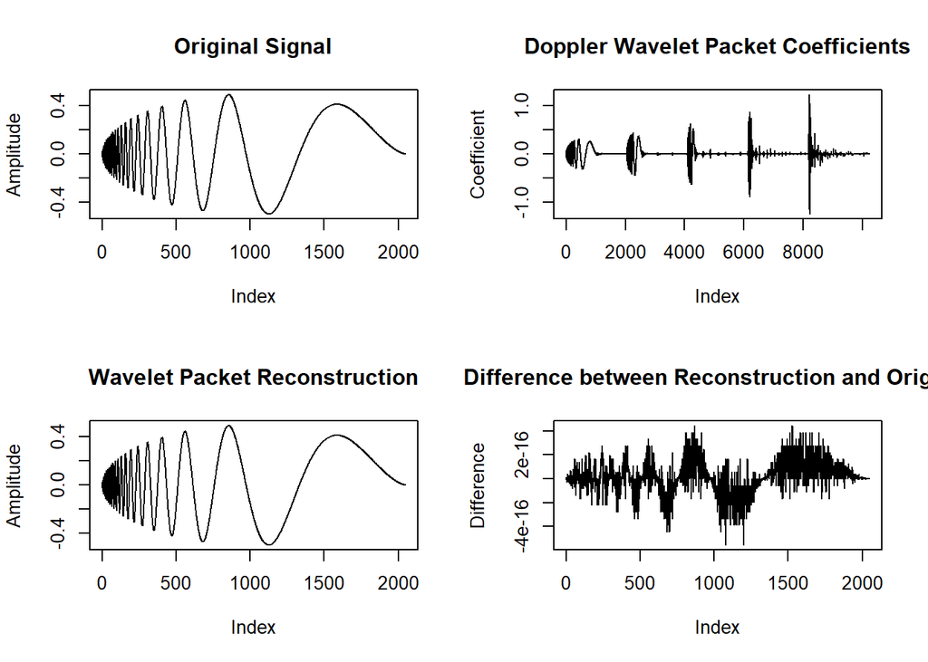

```r
# accurate summary should be: Min: -1.2486, Max: 1.23, Mean: 0.0086858


#perform the inverse wavelet packet transformation
a <- t(WP) %*% d

# Plotting results
par(mfrow = c(2, 2))
# Plot the original Doppler signal
plot(y, type = 'l', main = "Original Signal", xlab = "Index", ylab = "Amplitude")

# Plot the wavelet packet coefficients
plot(d, type = 'l', main = "Doppler Wavelet Packet Coefficients", xlab = "Index", ylab = "Coefficient")

# Plot the reconstructed signal
plot(a, type = 'l', main = "Wavelet Packet Reconstruction", xlab = "Index", ylab = "Amplitude")

# Plot the difference between the reconstructed and original signals
plot(a - y, type = 'l', main = "Difference between Reconstruction and Original", xlab = "Index", ylab = "Difference")
```

```r
#plots reconstruction error, which ideally is minimal.
```

**Explanation**

In this demo, we illustrate the application of wavelet packet transformations to analyze and reconstruct a Doppler signal. The Doppler signal is generally characterized by its sharp transitions, thus it is a great example for showcasing the effectiveness of wavelet transformations in capturing both global and localized signal features.

In the demo, using Haar wavelet filter coefficients, we construct a wavelet packet transformation matrix which is tailored to decompose the signal into multiple resolution levels. The Doppler signal is then reshaped into a column vector and transformed into the wavelet domain. This yields wavelet packet coefficients that show the signal’s frequency components across different scales.

We then apply the inverse transformation to reconstruct the original signal. We do this in order to demonstrate the fidelity of the transformation process. The minimal difference between the original and reconstructed signals is displayed to confirm the accuracy and robustness of the wavelet packet.

## WavmatND.R Demo

**Demo 1:** Denoising a Noisy Doppler Signal Using Non-Decimated Wavelet Transform

```r
library(WaveletMatrixProject)

# Define parameters for the signal and transformation
n <- 1000  # signal size setting
J <- floor(log2(n))  # Maximum decomposition level
k <- 4 #decomposition levels

# Generate a doppler signal
t <- seq(1/n, 1, length.out = n) # Time vector
s <- sqrt(t * (1 - t)) * sin((2 * pi * 1.05) / (t + 0.05))# Doppler signal formula

# Add Gaussian noise to the signal
sigma <- 0.1  # noise level
noise <- rnorm(length(s), mean = 0, sd = sigma) # Generate noise
sn <- s + noise # Noisy Doppler signal
var(sn) # Variance: Should be approximately 0.092 in order to correspond to correct Matlab calculation
```

```
#> [1] 0.09916485
```

```r
# Define the Haar wavelet filter
qmf <- c(1/sqrt(2), 1/sqrt(2))  # Haar wavelet

# Construct the ND wavelet transformation matrix
W <- WavmatND(qmf, n, k, 0)  # wavematND

# Define a weight matrix function
weight <- function(n, k) {# This function creates a diagonal weight matrix used for reconstructing the signal
  size <- (k + 1) * n  # Total size for the matrix (5000 when k = 4 and n = 1000)
  T <- matrix(0, nrow = size, ncol = size)  # Initialize an empty matrix

  # Assign weights so that the trace of T sums up to n (1000 in this case)
  for (i in 1:(k + 1)) {
    start_row <- (i - 1) * n + 1
    end_row <- i * n
    weight_value <- 1 / (k + 1)  # Equal weights for each block
    T[start_row:end_row, start_row:end_row] <- diag(weight_value, n, n)
  }

  return(T)
}


# Generate the weight matrix
T <- weight(n, k)


# Signal transformation
tsn <- W %*% matrix(sn, nrow = n, ncol = 1)
cat(sprintf("Variance of transformed signal : %f\n", var(tsn))) # Should be approximately 0.2721
```

```
#> Variance of transformed signal : 0.293545
```

```r
cat(sprintf("Variance of last detail level: %f\n", var(tsn[((k - 1) * n + 1):(k * n)]))) # Should be approximately 0.0132
```

```
#> Variance of last detail level: 0.013493
```

```r
# Extract detail levels and apply hard thresholding for denoising
temp <- tsn[(n + 1):length(tsn)]# Detail coefficients
threshold <- sqrt(2 * log(n) * var(tsn[(length(tsn) - n + 1):length(tsn)])) # Threshold value
temp[abs(temp) < threshold] <- 0 # Zero out small coefficients

# Reconstruct the signal using the inverse transformation
rs <- t(W) %*% T %*% c(tsn[1:n], temp)
trace <- sum(diag(T))# Verify the trace of T (should be n)
cat(sprintf("Trace of T: %f\n", trace)) # Should be 1000
```

```
#> Trace of T: 1000.000000
```

```r
cat(sprintf("Variance of reconstructed signal: %f\n", var(rs))) # Should be approximately 0.0777
```

```
#> Variance of reconstructed signal: 0.852038
```

```r
cat("Dimension of T: ", dim(T)) # 5000 5000
```

```
#> Dimension of T:  5000 5000
```

```r
cat("Dimension of T: ", dim(W)) # 5000 1000
```

```
#> Dimension of T:  5000 1000
```

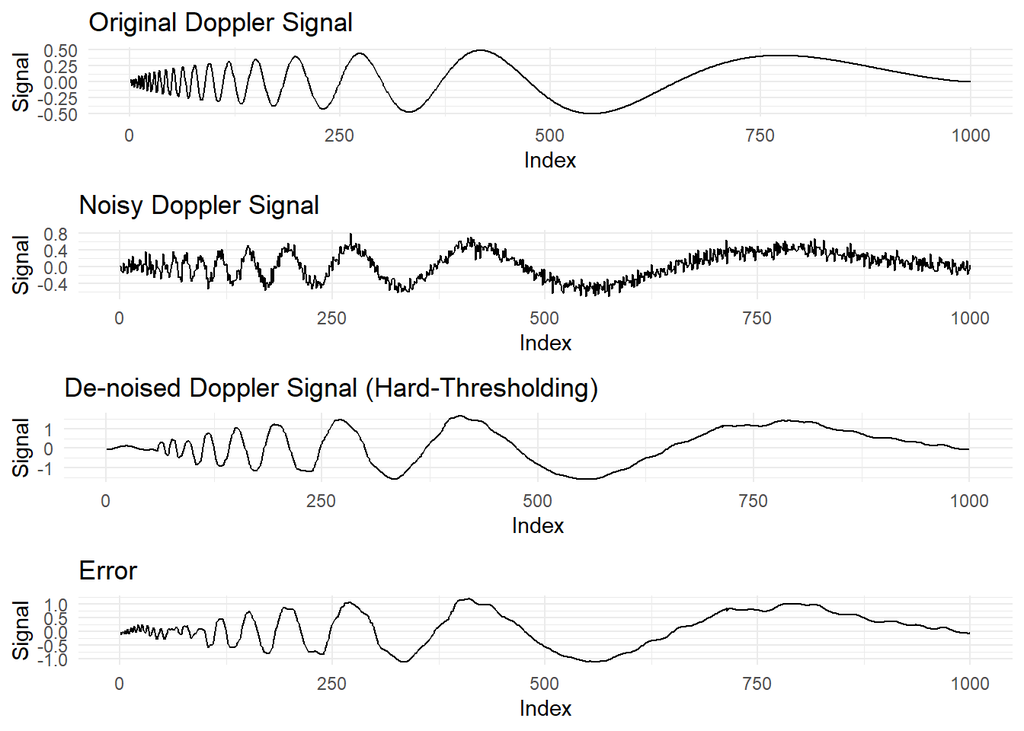

```r
# Create data frames for plotting

# Original signal
df_original <- data.frame(Index = 1:n, Signal = s)
# Noisy signal
df_noisy <- data.frame(Index = 1:n, Signal = sn)
# Denoised signal
df_denoised <- data.frame(Index = 1:n, Signal = rs)
# Reconstruction error
df_error <- data.frame(Index = 1:n, Signal = rs - s)

# Plot the original, noisy, denoised, and error signals
p1 <- ggplot2::ggplot(df_original, ggplot2::aes(x = Index, y = Signal)) +
  ggplot2::geom_line() +
  ggplot2::ggtitle('Original Doppler Signal') +
  ggplot2::theme_minimal()

p2 <- ggplot2::ggplot(df_noisy, ggplot2::aes(x = Index, y = Signal)) +
  ggplot2::geom_line() +
  ggplot2::ggtitle('Noisy Doppler Signal') +
  ggplot2::theme_minimal()

p3 <- ggplot2::ggplot(df_denoised, ggplot2::aes(x = Index, y = Signal)) +
  ggplot2::geom_line() +
  ggplot2::ggtitle('De-noised Doppler Signal (Hard-Thresholding)') +
  ggplot2::theme_minimal()

p4 <- ggplot2::ggplot(df_error, ggplot2::aes(x = Index, y = Signal)) +
  ggplot2::geom_line() +
  ggplot2::ggtitle('Error') +
  ggplot2::theme_minimal()

# Arrange plots in a 4x1 grid layout
gridExtra::grid.arrange(p1, p2, p3, p4, ncol = 1)
```

**Explanation:**

**Demo 2:** Denoising a Noisy Doppler Signal Using Non-Decimated Wavelet Transform with Weighted Reconstruction

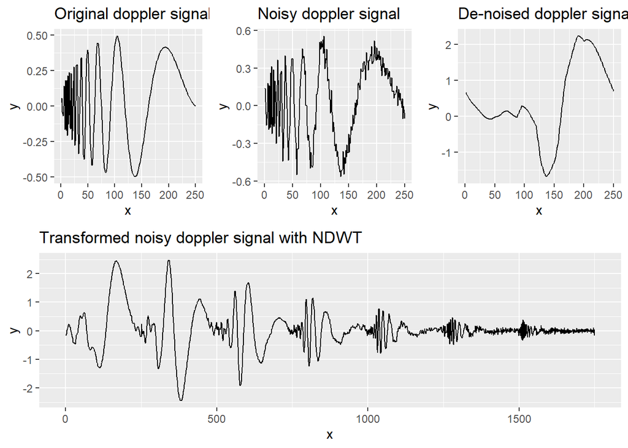

```r
library(WaveletMatrixProject)


# Set parameters for signal generation and transformation
sigma <- 0.05# Noise level
m <- 250  # Signal size
t <- seq(1/m, 1, length.out = m)# Time vector


# Generate a Doppler signal
s <- sqrt(t * (1 - t)) * sin((2 * pi * 1.05) / (t + 0.05))   # Doppler signal formula

# Add Gaussian noise to the signal
noise <- rnorm(m, 0, sigma)# Generate noise
sn <- s + noise  # Noisy doppler signal

# Compute decomposition level and wavelet filter
J <- floor(log2(m)) # Maximum level of decomposition for signal size m
k <- J - 1  # decomposition level
qmf <- c(1/sqrt(2), 1/sqrt(2))  # Haar wavelet filter coefficients

W <- WavmatND(qmf, m, k, 0)

# Define a function to create a weight matrix
weight <- function(m, k) {
  size <- (k + 1) * m # Total size for the matrix (5000 when k = 4 and n = 1000)
  T <- matrix(0, nrow = size, ncol = size)  # Initialize an empty matrix

  # Assign weights so that the trace of T sums up to n (1000 in this case)
  for (i in 1:(k + 1)) {
    start_row <- (i - 1) * m + 1
    end_row <- i * m
    weight_value <- 1 / (k + 1)  # Equal weights for each block
    T[start_row:end_row, start_row:end_row] <- diag(weight_value, m, m)
  }

  return(T)
}

# Generate the weight matrix
T <- weight(m, k)

# Transform the noisy signal using the wavelet matrix
tsn <- W %*% sn  # Transformed noisy signal

# Hard-thresholding for denoising; estimate noise level from the detail coefficients
sigmahat <- (var(tsn[(m + 1):length(tsn)][seq(1, length(tsn[(m + 1):length(tsn)]), 2)]) +
               var(tsn[(m + 1):length(tsn)][seq(2, length(tsn[(m + 1):length(tsn)]), 2)])) / 2

# Calculate the threshold for hard-thresholding
threshold <- sqrt(2 * log(k * m) * sigmahat)

# Apply hard-thresholding to the detail coefficients
snt <- tsn[(m + 1):length(tsn)] * (abs(tsn[(m + 1):length(tsn)]) > threshold)

# Combine approximation coefficients and thresholded detail coefficients
tsn_combined <- c(tsn[1:m], snt)

# Reconstruct the signal using the inverse transformation (transpose of W)
rs <- t(W) %*% T %*% tsn_combined  #  Apply weight matrix for proper reconstruction



# Plot denoising results

# Plot the original Doppler signal
p1 <- ggplot2::ggplot(data.frame(x = 1:m, y = s), ggplot2::aes(x, y)) +
  ggplot2::geom_line() +
  ggplot2::ggtitle("Original doppler signal") +
  ggplot2::xlim(0, m)


# Plot the noisy Doppler signal
p2 <- ggplot2::ggplot(data.frame(x = 1:m, y = sn), ggplot2::aes(x, y)) +
  ggplot2::geom_line() +
  ggplot2::ggtitle("Noisy doppler signal") +
  ggplot2::xlim(0, m)


# Prepare data for the de-noised signal plot
denoised_data <- data.frame(x = 1:m, y = rs[1:m])

# Plot the de-noised Doppler signal
p3 <- ggplot2::ggplot(denoised_data, ggplot2::aes(x, y)) +
  ggplot2::geom_line() +
  ggplot2::ggtitle("De-noised doppler signal") +
  ggplot2::xlim(0, m)


# Prepare data for the transformed noisy signal plot
tsn_data <- data.frame(x = 1:(m * (k + 1)), y = tsn)

# Plot the transformed noisy Doppler signal with NDWT
p4 <- ggplot2::ggplot(tsn_data, ggplot2::aes(x, y)) +
  ggplot2::geom_line() +
  ggplot2::ggtitle("Transformed noisy doppler signal with NDWT") +
  ggplot2::xlim(0, m * (k + 1))

# Arrange the plots in a 2x3 grid layout
gridExtra::grid.arrange(p1, p2, p3, p4, layout_matrix = matrix(c(1, 2, 3, 4, 4, 4), nrow = 2, byrow = TRUE))
```

# References

**A. Ijaz**, Wavelet analysis in R. Data Science - Big Data Analytics in Production., (available at https://ahsanijaz.github.io/2016-09-13-EMG/).

**B. Vidakovic**, Statistical Modeling by wavelets (Wiley-Blackwell, Oxford, 2013).

**G. P. Nason**, Wavelet methods in statistics with R (Springer New York, New York, NY, 2008).

**Reveille’s wavelets**, (available at https://people.tamu.edu/~brani/wavelet/).